## Assessment of severe weather impact using data in the NOAA Storm Database

#### Reproducible Research: Peer Assessment 2

#### 31/08/2020

### Synopsis

The NOAA storm database is an official publication of the National Oceanic and Atmospheric Administration (NOAA). It holds data relating to storm events which have been registered between January 1950 and November 2011.

This analysis focuses upon the most serious recorded storm events in relation to their health and economic consequences.  
Headlines derived from the dataset are:

- Most deaths are caused by the event **TORNADO**, which accounts for 30.6% of all recorded storm deaths (1,064 deaths).
- Most injuries are caused by the event **TORNADO**, which accounts for 39.8% of all recorded injuries (11,960 injuries).
- The most economic damage is caused by the event **FLOOD**, which accounts for 52.8% of material recorded damage ($138 billion).

### Data Processing

Data is expected in a file called *repdata_data_StormData.csv* in the working directory.

Read in the data and load it to a data frame named *sData*:

```r
zipfilePath <- paste("stormData.zip", sep = "")
         url <- "https://d396qusza40orc.cloudfront.net/repdata%2Fdata%2FStormData.csv.bz2"
         if (!file.exists("./repdata_data_StormData.csv")) {
                 if (!file.exists(zipfilePath)) {
                         download.file(url, zipfilePath)
                 }
                 unzip(zipfilePath, overwrite = TRUE)
         }

sData <- read.csv("repdata_data_StormData.csv", header = TRUE, sep = ",")
```

Convert the start/end date fields so they conform with POSIXct standards and can be used in calculations.

```r
sData$BGN_DATE <- strptime(sData$BGN_DATE, "%m/%d/%Y %H:%M:%S")
sData$END_DATE <- strptime(sData$END_DATE, "%m/%d/%Y %H:%M:%S")
```

Convert the damage values so they take the clearly distinguishable material multipliers (“H”, “K”, “M”, “B”, covering a range of hundreds to billions of dollars) into consideration and resolve to a $billion value for later aggregation.

```r
upVal <- data.frame(PROPDMGEXP = c("H", "K", "M", "B"), multP = c(100, 1000, 1000000, 1000000000))
sData <- merge(sData, upVal, by = "PROPDMGEXP")
sData$PROPDMG_M <- (sData$PROPDMG * sData$multP)/1000000000

upVal <- data.frame(CROPDMGEXP = c("H", "K", "M", "B"), multC = c(100, 1000, 1000000, 1000000000))
sData <- merge(sData, upVal, by = "CROPDMGEXP")
sData$CROPDMG_M <- (sData$CROPDMG * sData$multC)/1000000000

sData$TOTALDMG_M <- sData$PROPDMG_M + sData$CROPDMG_M
```

### Results

#### 1. Across the United States, which types of events (as indicated in the EVTYPE variable) are most harmful with respect to population health?

Impact to population health will be gauged by reference to the following variables:

- FATALITIES: The number of deaths attributed to a storm event; or
- INJURIES: The number of injuries attributed to a storm event.

This process derives a set of data to show us the 10 *EVTYPE* values that are associated to the highest number of deaths, as recorded in the *FATALITIES* field.

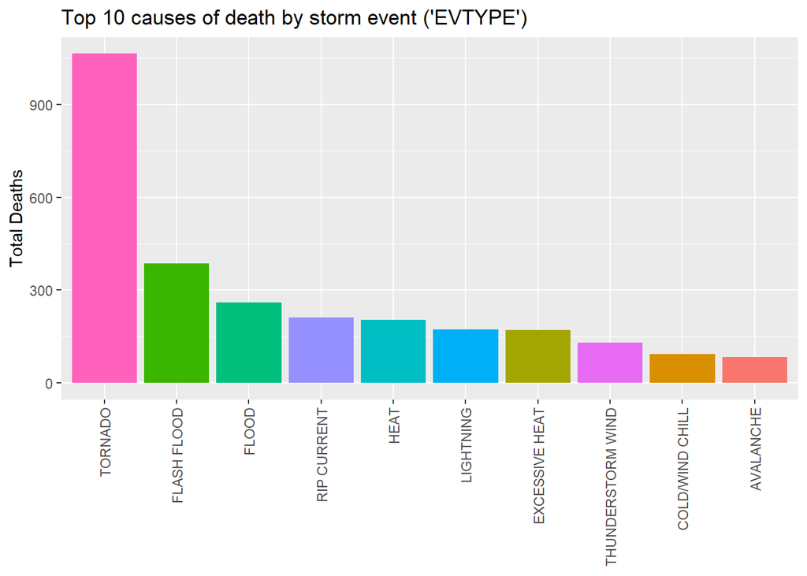

```r
require(dplyr)
require(ggplot2)

allDeaths <- sum(sData$FATALITIES, na.rm = TRUE)

tDeaths <- sData %>%
                group_by(EVTYPE) %>%
                summarise(tDeaths = sum(FATALITIES)) %>%
                arrange(desc(tDeaths))
mostDeaths <- head(tDeaths, 10)
mostDeaths$pc <- mostDeaths$tDeaths / allDeaths

ggplot(mostDeaths, aes(x = reorder(EVTYPE, desc(tDeaths)), y = tDeaths, fill = EVTYPE)) +
        geom_bar(stat = 'identity', position = "identity") +
        guides(fill = FALSE) +
        theme(axis.text.x = element_text(angle = 90, vjust = 0.5, hjust = 1)) +
        xlab(NULL) +
        ylab("Total Deaths") +
        labs(title = "Top 10 causes of death by storm event ('EVTYPE')")
```

The top 10 events account for 79.8% of all recorded deaths in the dataset. The most serious event is TORNADO which is responsible for 30.6% of deaths.

Then we can derive a set of data to show us the 10 *EVTYPE* values that are associated to the highest number of injuries, as recorded in the *INJURIES* field.

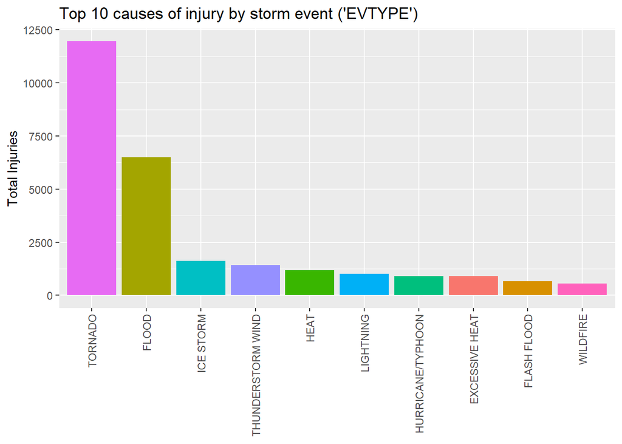

```r
allInjuries <- sum(sData$INJURIES, na.rm = TRUE)

tInjuries <- sData %>%
                group_by(EVTYPE) %>%
                summarise(tInjuries = sum(INJURIES)) %>%
                arrange(desc(tInjuries))
mostInjuries <- head(tInjuries, 10)
mostInjuries$pc <- mostInjuries$tInjuries / allInjuries

ggplot(mostInjuries, aes(x = reorder(EVTYPE, desc(tInjuries)), y = tInjuries, fill = EVTYPE)) +
        geom_bar(stat = 'identity', position = "identity") +
        guides(fill = FALSE) +
        theme(axis.text.x = element_text(angle = 90, vjust = 0.5, hjust = 1)) +
        xlab(NULL) +
        ylab("Total Injuries") +
        labs(title = "Top 10 causes of injury by storm event ('EVTYPE')")
```

The top 10 events account for 88.7% of all recorded injuries in the dataset. The most serious event is TORNADO which is responsible for 39.8% of injuries.

#### 2. Across the United States, which types of events have the greatest economic consequences?

Economic losses are quantified in the dataset by reference to the following:

- PROPDMG: Damage to property.
- CROPDMG: Damage to crops.

Multipliers are contained in the dataset which indicate whether the recorded costs are in thousands, millions or billions. Other values are contained in the dataset but have been ignored for the purposes of this analysis.

Where a multiplier is available it has been used to derive the cost in $billion. Property and crop damage has been added together to derive **total** damage. No adjustments have been made for inflation.

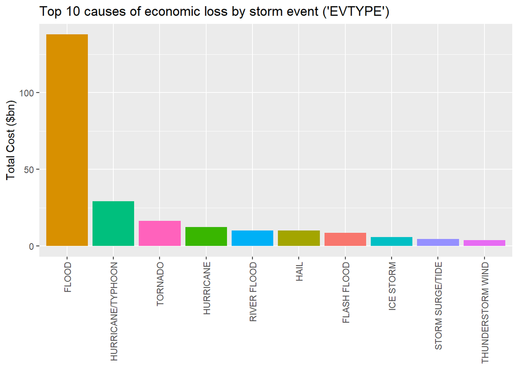

```r
require(scales)
allEcon <- sum(sData$TOTALDMG_M, na.rm = TRUE)

tEcon <- sData %>%
                group_by(EVTYPE) %>%
                summarise(tEcon = sum(TOTALDMG_M)) %>%
                arrange(desc(tEcon))
mostEcon <- head(tEcon, 10)
mostEcon$pc <- mostEcon$tEcon / allEcon

ggplot(mostEcon, aes(x = reorder(EVTYPE, desc(tEcon)), y = tEcon, fill = EVTYPE)) +
        geom_bar(stat = 'identity', position = "identity") +
        guides(fill = FALSE) +
        theme(axis.text.x = element_text(angle = 90, vjust = 0.5, hjust = 1)) +
        xlab(NULL) +
        ylab("Total Cost ($bn)") +
        scale_y_continuous(labels = comma) +
        labs(title = "Top 10 causes of economic loss by storm event ('EVTYPE')")
```

The top 10 events account for 91.6% of all economic losses recorded in the dataset. The most serious event is FLOOD which is responsible for 52.8% of the total recorded economic cost.